# D2SC: Weekly Assignments

Madison Chin

2024-10-30

# Initial Loading

```r
#in order to load the tidyverse library you must run the following

library(tidyverse)
library (ggdist)
library(knitr)
```

# Weekly Assignment 1

*In order to figure out which function loaded the tidyverse library, I searched the following into the Google Search Engine “load code chunk that loads tidyverse library”.

*I read the description given to me by first link “https://stackoverflow.com/questions/58289197/how-to-write-an-r-chunk-to-load-the-tidyverse” , which after reading for a little bit, I found that someone had used the “library” function in order to load the library.

*Then, I ran the above code chunk to figure out if the function would work for tidyverse.

*The core tidyverse packages were correctly added, but there seems to be some “Conflicts” in the Terminal after I ran it.

*But, after further research I found that these are not going to negatively affect any other code that I would write, but RStudio recommends using a “conflicted package” to turn these conflicts into errors.

```r
?tidyverse
#Below is the provided description after running #?tidyverse
```

The ‘tidyverse’ is a set of packages that work in harmony because they share common data representations and ‘API’ design. This package is designed to make it easy to install and load multiple ‘tidyverse’ packages in a single step. Learn more about the ‘tidyverse’ at https://www.tidyverse.org.

# Weekly Assignment 2

```r
read_csv("MFIndD_analogy.csv") #renamed
```

```
Error: 'MFIndD_analogy.csv' does not exist in current working directory ('C:/Users/mchin/OneDrive/Documents/GitHub/ADV-Topics-2---DSR-w-R/WeeklyAssignments/tidy_data').
```

The column that contains the unique identifier for each participate is titled “qualtrics_id” in the csv.

```r
setwd("~/GitHub/ADV-Topics-2---DSR-w-R/WeeklyAssignments/tidy_data")
analogy_data <- read_csv("Analogy_Dataset.csv")
#turning analogy data set into a usable and digestible variable.
```

```r
glimpse(analogy_data)
```

2a. The above line of code results in a short “glimpse” revealing that the data set has 792 rows and 6 columns, in the first couple of lines of the output, as seen in the console when run.

```r
analogy_data%>%
group_by(qualtrics_id)%>%
summarise(N=n()) %>%
  distinct() %>%
  count() %>%
  head(n = 1)
```

2b. The above function proves that there are [99] distinct people in the trial. I could not just apply a simple summary of the amount of qualtrics_id’s because there seemed to be some duplicates. This would mean that each ID is one person, so the number of unique id’s would be equivalent to the total number of people in the entire experiment.

```r
analogy_data%>%
group_by(qualtrics_id,trial_number)%>%
summarise(trial_number, count = n(), .groups = "drop_last")%>%
  count()
#I added the drop_last because I was getting an error"Adding missing grouping variables".
#I have checked Stack Overflow for answers, and this one seems to work!
```

2c.Yes, everyone has data from the same number of trials. Each unique Id has completed n trials, which for all are equal to [8] throughout the entire set. There are 99 rows which represents the number of people. So each person has data for 8 trials.

# Weekly Assignment 3

```r
num_of_trials <- analogy_data %>%
  group_by(qualtrics_id) %>%
  summarise(total_responses = n(), .groups = "drop") %>%  # Count total responses per ID
  left_join(                                                       # Join with the count of "Rel" responses
    analogy_data %>%
      filter(response_type == "Rel") %>%
      group_by(qualtrics_id) %>%
      summarise(num_of_trials = n(), .groups = "drop"),
    by = "qualtrics_id"
  ) %>%
  mutate(num_of_trials = coalesce(num_of_trials, 0)) %>%  # Replace NA with 0 for those with no "Rel" responses
  distinct(qualtrics_id, num_of_trials)

#I reworked this using coalesce to take into account the 0's that should be showing up in the manipulated
#dataset.

#I am also checking to see if num_of_trials runs as expected separately from storing the info in "num_of_trials". Which it works as expected!
```

```r
num_of_trials
```

```r
num_of_trials%>%
  ggplot(aes(x = num_of_trials))+
           geom_histogram()+
 labs(x = "number of 'Rel' responses",
      y = "amount of people ")
```

[output not shown]

2. The variable previously known as “num_of_trials”, now renamed to = amount of people, shows a disbursement of how many people responded with “Rel” a certain amount of times. It I also notice from the histogram that the majority of responses came from participants who responded to all of their trials with “Obj”, which would not have been found out without this variable.

```r
Analogy_Dataset.csv <- analogy_data #%>%
reshaped_data <- analogy_data %>%
  select(qualtrics_id, trial_number, response_type) %>%   # Select relevant columns
  filter(trial_number <= 8) %>%                          # Keep only the first 8 trials
  pivot_wider(names_from = trial_number,                 # Reshape from long to wide format
              values_from = response_type,
              names_prefix = "trial_") %>%               # Rename trials to trial_1, trial_2, etc.
  select(qualtrics_id,trial_1, trial_2, trial_3, trial_4, trial_5, trial_6, trial_7, trial_8) # Ensure only 9 columns (ID + 8 trials) and put them in order!

reshaped_data
```

```r
 #eval=FALSE (chunk header not showing on HTML)
analogy_data%>%
group_by(qualtrics_id,response_type = "Rel")%>%
summarise(trial_number, .groups = "drop_last")%>%
  distinct(qualtrics_id,response_type)


#The issue with this code is that response_type = "Rel" is not a valid way to filter the data within group_by(). Instead, this syntax is trying to create a new grouping variable that doesn't actually filter the data. As a result, the code does not return the expected results, and I ended up with a grouping that included unwanted response types.

#I also was having a hard time figuring out how to sort the trial numbers only using dplyr, but was able to get all of info on there by manually typing out trial_1 .... trial_8, but I had trouble optimizing this process to avoid possible human error. But all of the info is there!
```

# Weekly Assignment 4

```r
rationality_ques<- read_csv("MFIndD_REI.csv")
rationality_ques%>%
  head(6)
```

```r
dbl_response <-rationality_ques%>%
  mutate(response_dbl = case_when(
    response == "Strongly Disagree" ~ 1,
    response == "2" ~ 2,
    response == "3" ~ 3,
    response == "4" ~ 4,
    response == "Strongly Agree" ~ 5,
    TRUE ~ NA_real_ #to acknowledge and not replace any missing values
  ))
dbl_response
```

I wanted to have “TRUE ~ as.numeric(response)” instead of writing out response == 2,3,4, for efficiency. But, because this is a “base-r” function and not dplyr, I stuck to a redundant implementation.

```r
#items that need to be scored are marked as "neg" if not then marked with "NA"
new_score <- dbl_response%>%
  mutate(new_scored_response = if_else(
    rev_scoring == "neg", 6 - response_dbl,
    response_dbl,
    missing = response_dbl # this should account for all of the NA values
    ))

new_score
```

```r
new_score <- new_score %>%
mutate(is_equal = new_scored_response == scored_response)
# To check how many rows are not equal,filter those mismatches

mismatch_count <- new_score %>%
  filter(is_equal == FALSE) %>%
  count()

# View the count of mismatches
mismatch_count
```

n=0, So there are no mismatched values.

# Weekly Assignment 5

```r
# Question 1a
rei_summary <- new_score %>%
  filter(sub_type %in% c("EA", "EE", "RE", "RA")) %>% # Keep only relevant sub_types
  group_by(qualtrics_id, sub_type) %>%
  summarise(score = sum(new_scored_response, na.rm = TRUE), .groups = 'drop')

# Check the summary to confirm it has the right number of rows

rei_summary
```

```r
#Question 1b (part 1)

rei_summary <- new_score %>%
  filter(sub_type %in% c("EA", "EE", "RE", "RA")) %>% # Keep only relevant sub_types
  group_by(qualtrics_id, sub_type) %>%
  summarise(score = sum(new_scored_response, na.rm = FALSE), .groups = 'drop')

#The above code chunk is similar to this one here.The only difference is that the na.rm status is set to default where na.rm = false. There are indeed NA values scattered throughout, and I will summarize them in the following code chunk.


rei_summary
```

```r
# Question 1b (part two)
rei_summary%>%
  filter(is.na(score))

#This represents all people who have no "score" recorded for the respective trial(from the summary).
```

```r
# Question 1c Here I'll switch the na.rm "condition" back to true as I had it in my original (first code snippet) which I will replicate down below. This will assure that the scores are calculated and represented properly.
rei_summary <- new_score %>%
  filter(sub_type %in% c("EA", "EE", "RE", "RA")) %>% # Keep only relevant sub_types
  group_by(qualtrics_id, sub_type) %>%
  summarise(score = sum(new_scored_response, na.rm = TRUE), .groups = 'drop')

rei_summary
```

```r
# Question 2 Combining the summarized datasets from analogy and rei(that we just finished):
joined_data <- left_join(rei_summary,num_of_trials, by = ('qualtrics_id'))



#num_trials is the number of trials that the corresponding person (qualtrics_id) responded with "Rel".
joined_data
```

```r
#Question 3
# Scatterplot for relationship between REI score and newscore
ggplot(joined_data, aes(x = num_of_trials, y = score, color = sub_type)) +
  geom_point() +
  geom_smooth(method = "lm") +
  labs(title = "REI Scores by Subtype",
       y = " Sum of Sub Type Scores", x = " Number of Rel responses") +
  theme_minimal()
```

[output not shown]

# Weekly Assignment 6

```r
magic_ball <- read_csv("MFindD_probtask.csv")
magic_ball
```

2. part 1

```r
unique_conditions <- magic_ball %>% distinct(condition) %>%
  pull(condition)
#distinct conditions values
unique_conditions
```

2. part 2

```r
mean_reaction_times <- c()

for (cond in unique_conditions) {
  mean_reaction_time <- magic_ball %>%
    filter(condition == cond) %>%
    summarize(mean_reaction = mean(rt, na.rm = TRUE)) %>%
    pull(mean_reaction)

  mean_reaction_times <- c(mean_reaction_times, mean_reaction_time)
}

names(mean_reaction_times) <- unique_conditions
mean_reaction_times
```

```
 dots_EqSizeSep dots_EqSizeRand    blob_shifted    blob_stacked
       889.8202        879.6184        892.2855        847.5153
```

3. part 1

```r
# using across
magic_ball%>%
 group_by(condition) %>%
  summarise(across(c(rt, correct), mean, .names = "mean_{col}")) %>%
  rename(overall_accuracy = mean_correct) %>%
  select( mean_rt,condition, overall_accuracy)
```

| mean_rt | condition | overall_accuracy |
| --- | --- | --- |
| 892.2855 | blob_shifted | 0.6201515 |
| 847.5153 | blob_stacked | 0.6966667 |
| 879.6184 | dots_EqSizeRand | 0.6873840 |
| 889.8202 | dots_EqSizeSep | 0.6176562 |

3. part 2

```r
# without using across
magic_ball %>%
  group_by(condition) %>%
  summarise(
    mean_rt = mean(rt),
    overall_accuracy = mean(correct)
  )%>%
  select(mean_rt,condition, overall_accuracy)
```

# Weekly Assignment 7

```r
prob_data <- magic_ball
```

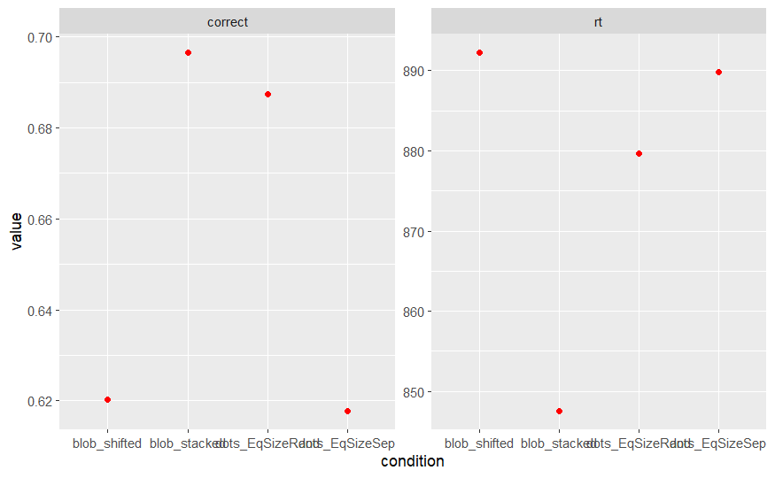

```r
#Running the given code chunk
prob_data %>%
group_by(condition) %>%
summarise(across(c(rt, correct), mean)) %>%
pivot_longer(c(rt, correct)) %>%
ggplot(aes(y = value, x = condition)) +
geom_point(color = "red") +
facet_wrap(~name, scales = "free")
```

1a. Blob_shifted, for the “correct” plot, there seems to be a lower value, than in the rt plot, where the participants scored significantly higher (with a reaction time above 890 secs).

Blob_stacked, for the “correct” plot, there seems to be a higher amount of correct answers than in the rt plot (reaction time), but the true value in terms of the “hundreds”, the rt value is significantly higher. This relation is hard to understand from the graph for someone who is not familiar with the data.

dots_EqSizeSep - People had a higher correct rate here in comparison to their reaction time (rt) it seems that they took longer than their “Rand” counter part.

dots_EqSizerRand - Significantly higher “correct” rate, than “Sep”, and lower reaction time in relation to its “Sep” counterpart.

1b) Because the reaction time (rt) graph and the accuracy (correct) graph have different numerical ranges—rt values are in the high 800s, while correct values range around 0.60 to 0.70—it makes it challenging to compare both sides of the graph directly. This difference in scales can lead to misinterpretation of the data’s significance. Graphs with such disparate ranges often require careful consideration or different visualization techniques to ensure clear, accurate comparisons. Additionally, the overlapping names of the conditions at the bottom make it hard to read, further complicating the comparison.

1c. What’s hard to “see” in this plot:

Detailed Differences: It’s challenging to see more nuanced differences or variance within each condition because the plot only shows mean values. (We would need a larger graph though.)

As I mentioned before, there are also issues with reading the conditions that are at the bottom of the graph. I had to squint to read them.

Distribution of Data: We miss out on how data points are distributed within each condition. Is there a lot of variance? Are there outliers? This type of plot doesn’t convey that information well.(Trends in the graph take a lot of effort to read)

2. (For some reason, when I had a shorter bit of code, “correct” was not being piped in properly)

```r
#Double checking summary is correct/Summarizing to get the proportion of the data correct.
prob_data_summary <- prob_data %>%
  group_by(SubID, condition) %>%
  summarise(prop_corr = mean(correct), .groups = 'drop')  # Ensure ungrouping

# Check the summarized data
print(prob_data_summary)
```

| SubID | condition | prop_corr |
| --- | --- | --- |
| R_0SrX3uRtXaupbhv | dots_EqSizeRand | 0.4696970 |
| R_0SrX3uRtXaupbhv | dots_EqSizeSep | 0.6666667 |
| R_0V8O8mrLiHO3Ghj | blob_shifted | 0.4696970 |
| R_0V8O8mrLiHO3Ghj | blob_stacked | 0.7045455 |
| R_1BW5H5J1jQFEpuk | blob_shifted | 0.5303030 |
| R_1BW5H5J1jQFEpuk | blob_stacked | 0.7045455 |
| R_1E0SHQwiV6CXRoo | blob_shifted | 0.5833333 |
| R_1E0SHQwiV6CXRoo | blob_stacked | 0.7121212 |
| R_1F9e3CRe4Tb8JhE | blob_shifted | 0.5454545 |
| R_1F9e3CRe4Tb8JhE | blob_stacked | 0.6136364 |

[output cut: 188 more lines]

```r
# Calculate mean proportion correct for each condition
mean_prop_summary <- prob_data_summary %>%
  group_by(condition) %>%
  summarise(mean_prop_corr = mean(prop_corr),
            sd_prop_corr = sd(prop_corr),  # Standard deviation for error bars(to help with readability of the plot)
            n = n(), .groups = 'drop')
```

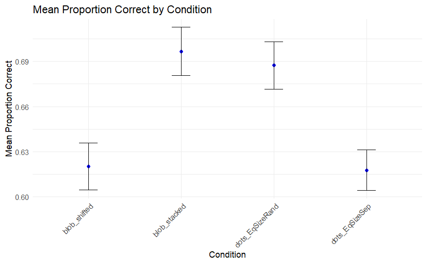

```r
mean_prop_summary %>%
  ggplot(aes(x = condition, y = mean_prop_corr)) +
  geom_point(color = "blue") +
  geom_errorbar(aes(ymin = mean_prop_corr - sd_prop_corr / sqrt(n),
                    ymax = mean_prop_corr + sd_prop_corr / sqrt(n)),
                width = 0.2) +
  theme_minimal() +
  labs(title = "Mean Proportion Correct by Condition",
       x = "Condition", y = "Mean Proportion Correct") +
  theme(axis.text.x = element_text(angle = 45, hjust = 1))
```

Rotated Axis Labels: Rotated x-axis labels for better readability of the condition names. This avoids overlapping and cluttering of labels.

```r
# Create plot with distributional information
prob_data_summary %>%
  ggplot(aes(x = condition, y = prop_corr)) +
  ggdist::stat_slab() +  # Adds a distributional layer to show the density of the data
  geom_point(aes(x = condition, y = mean(prop_corr)),
             color = "blue", position = position_nudge(y = 0.05)) +  # Offset mean points for clarity
  theme_minimal() +
  labs(title = "Distribution of Proportion Correct by Condition",
       x = "Condition", y = "Proportion Correct") +
  theme(axis.text.x = element_text(angle = 45, hjust = 1))  # Improved readability
```

[output not shown]

theme(axis.text.x = element_text(angle = 45, hjust = 1)): Ensures the condition names are readable by rotating the x-axis labels.z.

# Weekly Assignment 8